# Segmenter Basic Checks

Sanity checks for `segments_` and `messages_segmented_`.

Will eventually be automated as part of the pipeline and may no longer be a necessary part of manual QA so long as the checks were run as part of the pipeline you will to check.

Author: Jenn Van Osdel  
Last Updated: August 24, 2022

```python
import pandas as pd
import matplotlib.pyplot as plt
import matplotlib as mpl
from datetime import datetime

from config import DATASET_OLD, DATASET_NEW_MONTHLY_INT, FRAGMENTS_TABLE, SEGMENTS_TABLE, MESSAGES_SEGMENTED_TABLE, NUM_SEGS_DIFF_THRESHOLD

mpl.rcParams['figure.facecolor'] = 'white'
pd.set_option("max_rows", 40)
```

# FINAL QUERIES FOR AUTOMATED QA

This notebook runs the queries on every date shard in the table, but these queries can be used directly in Airflow for a given day instead.

```python
q = f'''
SELECT DISTINCT _table_suffix as shard_date
FROM `{DATASET_NEW_MONTHLY_INT}.{SEGMENTS_TABLE}*`
ORDER BY shard_date
'''

shard_dates_segments = pd.read_gbq(q, project_id='world-fishing-827', dialect='standard')
```

```python
q = f'''
SELECT DISTINCT _table_suffix as shard_date
FROM `{DATASET_NEW_MONTHLY_INT}.{MESSAGES_SEGMENTED_TABLE}*`
ORDER BY shard_date
'''

shard_dates_messages_segmented = pd.read_gbq(q, project_id='world-fishing-827', dialect='standard')
```

```python
q = f'''
SELECT DISTINCT _table_suffix as shard_date
FROM `{DATASET_NEW_MONTHLY_INT}.{FRAGMENTS_TABLE}*`
ORDER BY shard_date
'''

shard_dates_fragments = pd.read_gbq(q, project_id='world-fishing-827', dialect='standard')
```

```python
try:
    assert(shard_dates_segments.shard_date.to_list() == shard_dates_messages_segmented.shard_date.to_list() == shard_dates_fragments.shard_date.to_list())
except:
    print("ERROR: Shard dates do not match between tables. DO NOT CONTINUE QA BEFORE RECONCILING!")
```

## Check num_segs against 30-day rolling average for a given day

Cost: 0MB

```python
def check_rolling_average(shard_date):
    # Query to get the 30-day rolling average for a particular day
    q = f'''
    WITH

    calc AS (
    SELECT COUNT(*)/30 rolling_average
    FROM `{DATASET_NEW_MONTHLY_INT}.{SEGMENTS_TABLE}*`
    WHERE _TABLE_SUFFIX BETWEEN FORMAT_TIMESTAMP('%Y%m%d', DATE_SUB(PARSE_DATE("%Y%m%d", "{shard_date}"), INTERVAL 30 DAY)) AND FORMAT_TIMESTAMP('%Y%m%d', DATE_SUB(PARSE_DATE("%Y%m%d", "{shard_date}"), INTERVAL 1 DAY))
    )

    SELECT
    IF(ABS((SELECT rolling_average FROM calc) - COUNT(*))/(SELECT rolling_average FROM calc) < {NUM_SEGS_DIFF_THRESHOLD}, 1, 0) as good_num_segs,
    FROM `{DATASET_NEW_MONTHLY_INT}.{SEGMENTS_TABLE}{shard_date}`
    '''

    num_segs_check = pd.read_gbq(q, project_id='world-fishing-827', dialect='standard')

    try:
        for col in num_segs_check.columns:
            assert(num_segs_check.iloc[0][col] == 1)
        return True
    except:
        print(f"FAILED: {shard_date}")
        return False
```

```python
# Cannot perform the check for the first 30 days reliably.
all_passed = True
failed_dates = []
for date in shard_dates_segments.shard_date[30:]:
    outcome = check_rolling_average(date)
    if not outcome:
        all_passed = False
        failed_dates.append(date)

failed_dates = [datetime.strptime(date, "%Y%m%d").strftime('%Y-%m-%d') for date in failed_dates]

if all_passed:
    print("ALL PASSED")
```

```
FAILED: 20200221
FAILED: 20200225
FAILED: 20200301
FAILED: 20200311
FAILED: 20200316
FAILED: 20200502
FAILED: 20200503
FAILED: 20200504
FAILED: 20200506
FAILED: 20200512
FAILED: 20200903
FAILED: 20201023
FAILED: 20201027
```

```python
if not all_passed:
    q = f'''
    WITH

    segment_data AS (
        SELECT DATE(timestamp) as date, seg_id
        FROM `{DATASET_NEW_MONTHLY_INT}.{SEGMENTS_TABLE}*`
    )

    SELECT
    date,
    EXTRACT(YEAR from date) as year,
    COUNT(*) AS num_segs,
    COUNT(DISTINCT seg_id) AS num_segs_distinct,
    FROM segment_data
    GROUP BY date
    ORDER BY date
    '''

    # print(q)
    df_segs_daily = pd.read_gbq(q, project_id='world-fishing-827', dialect='standard')

    assert(df_segs_daily[df_segs_daily.num_segs != df_segs_daily.num_segs_distinct].shape[0] == 0)

    df_segs_daily['num_segs_30day_avg'] = df_segs_daily.rolling(window=30, closed='left').num_segs.mean()
    df_segs_daily['num_segs_30day_avg_diff'] = df_segs_daily.num_segs - df_segs_daily.num_segs_30day_avg
    df_segs_daily['num_segs_30day_avg_diff_perc'] = (df_segs_daily.num_segs - df_segs_daily.num_segs_30day_avg)/df_segs_daily.num_segs_30day_avg
    df_segs_daily = df_segs_daily.set_index(pd.to_datetime(df_segs_daily.date))
```

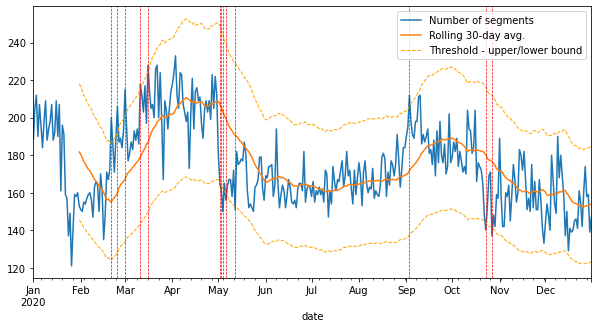

```python
if not all_passed:
    fig = plt.figure(figsize=(10, 5))
    ax = df_segs_daily.num_segs.plot(label="Number of segments")
    df_segs_daily.num_segs_30day_avg.plot(label="Rolling 30-day avg.")
    (df_segs_daily.num_segs_30day_avg * 1.2).plot(label="Threshold - upper/lower bound", c="orange", ls="--", lw=1)
    (df_segs_daily.num_segs_30day_avg * 0.8).plot(label="_nolegend_", c="orange", ls="--", lw=1)
    for date in failed_dates:
        plt.axvline(date, c="red", ls='--', lw=0.7)
    plt.legend()
    plt.show()
```

## Sanity checks

### `segments_`

- `daily_message_count` > 0
- `cumulative_msg_count` > 0
- ssvid portion of `frag_id` == `ssvid`
- DATE(`frag_id`) >= DATE(`seg_id`)
- No duplicate `seg_id` (still broken in `20220329` version)

##### Validity checks

*Cost: ~18KB depending on size of day*

```python
def check_segments_validity(shard_date):
    q = f'''
    CREATE TEMP FUNCTION timestamp_from_id(frag_id STRING) AS
    ((
        SELECT
        TIMESTAMP(STRING_AGG(arr, '-'))
        FROM UNNEST(SPLIT(frag_id, '-')) AS arr WITH OFFSET as offset
        WHERE offset BETWEEN 1 and 3
    ));

    SELECT
    IF(SUM(IF(daily_msg_count > 0, 1, 0)) = COUNT(*), 1, 0) as valid_daily_msg_ct,
    IF(SUM(IF(cumulative_msg_count > 0, 1, 0)) = COUNT(*), 1, 0) as valid_cumul_msg_ct,
    IF(SUM(IF(LEFT(frag_id, STRPOS(frag_id, "-")-1) = ssvid, 1, 0)) = COUNT(*), 1, 0) as valid_frag_id_ssvid,
    IF(SUM(IF(timestamp_from_id(frag_id) >= timestamp_from_id(seg_id), 1, 0)) = COUNT(*), 1, 0) as valid_frag_seg_pair,
    FROM `{DATASET_NEW_MONTHLY_INT}.{SEGMENTS_TABLE}{shard_date}`
    '''
    # print(q)
    segment_validity_check = pd.read_gbq(q, project_id='world-fishing-827', dialect='standard')

    try:
        for col in segment_validity_check.columns:
            assert(segment_validity_check.iloc[0][col] == 1)
        return True
    except:
        print(f"FAILED {shard_date}")
        return False
```

```python
all_passed = True
for date in shard_dates_segments.shard_date:
    outcome = check_segments_validity(date)
    if all_passed and not outcome:
        all_passed = False

if all_passed:
    print("ALL PASSED")
```

```
ALL PASSED
```

### `messages_segmented_`

- DATE(`frag_id`) == DATE(`timestamp`)
- DATE(`frag_id`) >= DATE(`seg_id`)
- `source` is one of [`spire` , `orbcomm`]
- `type` starts with `AIS.`
- `receiver_type` is one of [`satellite` , `terrestrial`]
- Check that we never get invalid values for certain columns: `lon`, `lat`, `course`, `heading`, `speed`, `shipname`, `callsign`, `destination`

*Cost: ~5-6MB depending on size of day*

```python
def check_messages_segmented_validity(shard_date):
    q = f'''
    CREATE TEMP FUNCTION time_from_segid_array(arr ARRAY<STRING>) AS
    ((
        SELECT TIMESTAMP(CONCAT(arr[OFFSET(1)], '-', arr[OFFSET(2)], '-', arr[OFFSET(3)]))
    ));

    SELECT
    IF(SUM(IF(DATE(time_from_segid_array(SPLIT(frag_id, '-'))) = DATE(timestamp), 1, 0)) = COUNTIF(frag_id IS NOT NULL), 1, 0) as valid_frag_id_timestamp,
    IF(SUM(IF(LEFT(frag_id, STRPOS(frag_id, "-")-1) = ssvid, 1, 0)) = COUNTIF(frag_id IS NOT NULL), 1, 0) as valid_frag_id_ssvid,
    IF(SUM(IF(TIMESTAMP(time_from_segid_array(SPLIT(frag_id, '-'))) >= TIMESTAMP(time_from_segid_array(SPLIT(seg_id, '-'))), 1, 0)) = COUNTIF((frag_id IS NOT NULL) AND (seg_id IS NOT NULL)), 1, 0) as valid_frag_seg_pair,
    IF(SUM(IF(source IN ("spire", "orbcomm"), 1, 0)) = COUNT(*), 1, 0) as valid_source,
    IF(SUM(IF(STARTS_WITH(type, "AIS"), 1, 0)) = COUNT(*), 1, 0) as valid_type,
    IF(SUM(IF(receiver_type IN ("satellite", "terrestrial"), 1, 0)) = COUNT(*), 1, 0) as valid_receiver_type,
    IF(COUNTIF((lon IS NOT NULL) AND (lon <= -181 OR lon >= 181)) = 0, 1, 0) AS valid_lon,
    IF(COUNTIF((lat IS NOT NULL) AND (lat <= -91 OR lat >= 91)) = 0, 1, 0) AS valid_lat,
    IF(COUNTIF((course IS NOT NULL) AND (course < 0 OR course >= 360)) = 0, 1, 0) AS valid_course,
    IF(COUNTIF((heading IS NOT NULL) AND (heading < 0 OR heading >= 360)) = 0, 1, 0) AS valid_heading,
    IF(COUNTIF((speed IS NOT NULL) AND (speed < 0 OR speed >= 102.3)) = 0, 1, 0) AS valid_speed_most,
    IF(COUNTIF((type = 'AIS.27') AND (speed IS NOT NULL) AND (speed < 0 OR speed >= 63)) = 0, 1, 0) AS valid_speed_AIS27,
    IF(COUNTIF((type IN ('AIS.5', 'AIS.19', 'AIS.21', 'AIS.24')) AND (shipname = '@@@@@@@@@@@@@@@@@@@@')) = 0, 1, 0) AS valid_shipname,
    IF(COUNTIF((type IN ('AIS.5', 'AIS.24')) AND (shipname = '@@@@@@@')) = 0, 1, 0) AS valid_callsign,
    IF(COUNTIF((type = 'AIS.5') AND (destination = '@@@@@@@@@@@@@@@@@@@@')) = 0, 1, 0) AS valid_destination,
    FROM `{DATASET_NEW_MONTHLY_INT}.{MESSAGES_SEGMENTED_TABLE}{shard_date}`
    '''

    messages_segmented_check_1 = pd.read_gbq(q, project_id='world-fishing-827', dialect='standard')

    try:
        for col in messages_segmented_check_1.columns:
            assert(messages_segmented_check_1.iloc[0][col] == 1)
        return True
    except:
        print(f"FAILED: {shard_date}")
        return False
```

```python
all_passed = True
for date in shard_dates_messages_segmented.shard_date:
    outcome = check_messages_segmented_validity(date)
    if all_passed and not outcome:
        all_passed = False

if all_passed:
    print("ALL PASSED")
```

```
ALL PASSED
```

### `fragments_`

- `msg_count` > 0
- timestamp portion of `frag_id` == `first_msg_timestamp`
- date portion of `frag_id` == date portion of `timestamp` and `last_msg_timestamp`
- ssvid portion of `frag_id` == `ssvid`
- No duplicate `frag_id`

```python
def check_fragments_validity(shard_date):
    q = f'''
    CREATE TEMP FUNCTION timestamp_from_id(frag_id STRING) AS
    ((
        SELECT
        TIMESTAMP(STRING_AGG(arr, '-'))
        FROM UNNEST(SPLIT(frag_id, '-')) AS arr WITH OFFSET as offset
        WHERE offset BETWEEN 1 and 3
    ));

    SELECT
    IF(SUM(IF(msg_count > 0, 1, 0)) = COUNT(*), 1, 0) as valid_msg_count,
    IF(SUM(IF(timestamp_from_id(frag_id) = first_msg_timestamp, 1, 0)) = COUNT(*), 1, 0) as valid_first_msg_timestamp,
    IF(SUM(IF(DATE(timestamp_from_id(frag_id)) = DATE(timestamp), 1, 0)) = COUNT(*), 1, 0) as valid_timestamp,
    IF(SUM(IF(DATE(timestamp_from_id(frag_id)) = DATE(last_msg_timestamp), 1, 0)) = COUNT(*), 1, 0) as valid_last_msg_timestamp,
    IF(SUM(IF(LEFT(frag_id, STRPOS(frag_id, "-")-1) = ssvid, 1, 0)) = COUNT(*), 1, 0) as valid_frag_id_ssvid,
    FROM `{DATASET_NEW_MONTHLY_INT}.{FRAGMENTS_TABLE}{shard_date}`
    '''
    # print(q)
    fragment_validity_check = pd.read_gbq(q, project_id='world-fishing-827', dialect='standard')

    try:
        for col in fragment_validity_check.columns:
            assert(fragment_validity_check.iloc[0][col] == 1)
        return True
    except:
        print(f"FAILED {shard_date}")
        return False
```

```python
all_passed = True
for date in shard_dates_fragments.shard_date:
    outcome = check_fragments_validity(date)
    if all_passed and not outcome:
        all_passed = False

if all_passed:
    print("ALL PASSED")
```

```
ALL PASSED
```

### Duplicates check for `segments_` and `fragments_`

*Cost: ~6KB depending on size of day*

```python
def check_duplicate_ids(table, id_col, shard_date):
    q = f'''
    WITH

    duplicate_ids AS (
    SELECT
    {id_col}, COUNT(*)
    FROM `{table}{shard_date}`
    GROUP BY {id_col}
    HAVING COUNT(*) > 1
    )

    SELECT
    IF(COUNT(*) = 0, 1, 0) as dupe_check
    FROM duplicate_ids
    '''
    # print(q)
    duplicate_ids_check = pd.read_gbq(q, project_id='world-fishing-827', dialect='standard')

    try:
        for col in duplicate_ids_check.columns:
            assert(duplicate_ids_check.iloc[0][col] == 1)
        return True
    except:
        print(f"FAILED: {shard_date}")
        return False
```

```python
all_passed = True
for date in shard_dates_segments.shard_date:
    outcome = check_duplicate_ids(f"{DATASET_NEW_MONTHLY_INT}.{SEGMENTS_TABLE}", "seg_id", date)
    if all_passed and not outcome:
        all_passed = False

if all_passed:
    print("ALL PASSED")
```

```
ALL PASSED
```

```python
all_passed = True
for date in shard_dates_segments.shard_date:
    outcome = check_duplicate_ids(f"{DATASET_NEW_MONTHLY_INT}.{FRAGMENTS_TABLE}", "frag_id", date)
    if all_passed and not outcome:
        all_passed = False

if all_passed:
    print("ALL PASSED")
```

```
ALL PASSED
```

### Fragment/segment join checks

Make sure there is a one-to-one relationship between `segments_` and `framents_` on `frag_id` on every shard date. There should be a one-to-one relationship across all dates as well, but this is designed to be run on a daily basis. The construction of the `frag_id` should keep `frag_id` from having a duplicate on any other shard date by definition, but that is still an assumption we make here to keep checks at the daily level.

```python
def check_seg_frag_relationship(seg_table, frag_table, shard_date):
    q = f'''
    SELECT
        IF(COUNTIF((seg.frag_id IS NULL) OR (frag.frag_id IS NULL)) = 0, 1, 0) as count_bad,
    FROM `{seg_table}{shard_date}` seg
    FULL OUTER JOIN `{frag_table}{shard_date}` frag
    USING (frag_id)
    '''
    # print(q)
    seg_frag_relationship_check = pd.read_gbq(q, project_id='world-fishing-827', dialect='standard')

    try:
        for col in seg_frag_relationship_check.columns:
            assert(seg_frag_relationship_check.iloc[0][col] == 1)
        return True
    except:
        print(f"FAILED: {shard_date}")
        return False
```

```python
all_passed = True
for date in shard_dates_segments.shard_date:
    outcome = check_seg_frag_relationship(f"{DATASET_NEW_MONTHLY_INT}.{SEGMENTS_TABLE}", f"{DATASET_NEW_MONTHLY_INT}.{FRAGMENTS_TABLE}", date)
    if all_passed and not outcome:
        all_passed = False

if all_passed:
    print("ALL PASSED")
```

```
ALL PASSED
```

# EXPLORATORY ANALYSIS FOR `num_segs` METRIC

### !!! YOU CAN IGNORE THIS IF YOU JUST WANT TO DO THE QA QUERIES !!!

Finding a metric that flags when the number of segments in a day deviates far enough from the norm to cause concern. This query will not stop the pipeline but instead raise a flag that the day's data should be inspected against historical segment numbers.

*NOTE: If you would like to run, you will need to uncomment the cells below.*

```python
# q = f'''
# WITH

# segment_data AS (
#     SELECT DATE(timestamp) as date, seg_id, ssvid, closed, message_count,
#     TIMESTAMP_DIFF(last_msg_timestamp, first_msg_timestamp, SECOND)/3600 as seg_hours,
#     (SELECT COUNT(*) FROM UNNEST(shipnames) WHERE value IS NOT NULL) > 0 AS valid_shipname
#     FROM `{DATASET_OLD}.{SEGMENTS_TABLE}*`
# )

# SELECT
# date,
# EXTRACT(YEAR from date) as year,
# COUNT(*) AS num_segs,
# COUNT(DISTINCT seg_id) AS num_segs_distinct,
# COUNTIF(closed) AS num_closed,
# COUNTIF(closed)/COUNT(*) AS ratio_closed,
# COUNTIF(valid_shipname) AS num_valid_shipname,
# COUNTIF(valid_shipname)/COUNT(*) AS ratio_valid_shipname,
# AVG(IF(seg_hours = 0, NULL, LOG10(seg_hours))) AS avg_log_length,
# COUNTIF(seg_hours = 0) AS num_zero_length,
# COUNTIF(seg_hours = 0)/COUNT(*) as ratio_zero_length
# FROM segment_data
# GROUP BY date
# ORDER BY date
# '''

# # print(q)
# df_segs_old_daily = pd.read_gbq(q, project_id='world-fishing-827', dialect='standard')
```

```python
# df_segs_old_daily_aug1 = df_segs_old_daily[df_segs_old_daily.date >= '2020-08-01'].reset_index(drop=True).copy()
# df_segs_old_daily_aug1['num_segs_7day_avg'] = df_segs_old_daily_aug1.rolling(window=7, closed='left').num_segs.mean()
# df_segs_old_daily_aug1['num_segs_7day_avg_diff'] = df_segs_old_daily_aug1.num_segs - df_segs_old_daily_aug1.num_segs_7day_avg
# df_segs_old_daily_aug1['num_segs_7day_avg_diff_perc'] = (df_segs_old_daily_aug1.num_segs - df_segs_old_daily_aug1.num_segs_7day_avg)/df_segs_old_daily_aug1.num_segs_7day_avg
# df_segs_old_daily_aug1['num_segs_30day_avg'] = df_segs_old_daily_aug1.rolling(window=30, closed='left').num_segs.mean()
# df_segs_old_daily_aug1['num_segs_30day_avg_diff'] = df_segs_old_daily_aug1.num_segs - df_segs_old_daily_aug1.num_segs_30day_avg
# df_segs_old_daily_aug1['num_segs_30day_avg_diff_perc'] = (df_segs_old_daily_aug1.num_segs - df_segs_old_daily_aug1.num_segs_30day_avg)/df_segs_old_daily_aug1.num_segs_30day_avg
# df_segs_old_daily_aug1
```

```python
# ax = df_segs_old_daily_aug1.plot(x='date', y='num_segs', ylim=(125000, 400000))
# df_segs_old_daily_aug1.plot(ax=ax, x='date', y='num_segs_7day_avg', ylim=(125000, 400000))
# df_segs_old_daily_aug1.plot(ax=ax, x='date', y='num_segs_30day_avg', ylim=(125000, 400000))

# plt.title("Number of segments per day")
# plt.show()
```

```python
# fig, (ax0, ax1) = plt.subplots(nrows=1, ncols=2, figsize=(15,5))
# df_segs_old_daily_aug1.num_segs_7day_avg_diff_perc.hist(ax=ax0, bins=100)
# df_segs_old_daily_aug1.num_segs_30day_avg_diff_perc.hist(ax=ax1, bins=100)
# ax0.set_title("Percent difference\nfrom 7-day rolling average")
# ax1.set_title("Percent difference\nfrom 30-day rolling average")
# plt.show()
```

```python
# ax = df_segs_old_daily_aug1.plot(x='date', y='num_segs_7day_avg_diff_perc', label="7-day")#, ylim=(0, 400000))
# df_segs_old_daily_aug1.plot(ax=ax, x='date', y='num_segs_30day_avg_diff_perc', label="30-day")#, ylim=(0, 400000))

# diff_10perc_7day = df_segs_old_daily_aug1[df_segs_old_daily_aug1.num_segs_7day_avg_diff_perc.abs() > 0.1].copy().reset_index(drop=True)
# diff_10perc_30day = df_segs_old_daily_aug1[df_segs_old_daily_aug1.num_segs_30day_avg_diff_perc.abs() > 0.1].copy().reset_index(drop=True)
# diff_20perc_7day = df_segs_old_daily_aug1[df_segs_old_daily_aug1.num_segs_7day_avg_diff_perc.abs() > 0.2].copy().reset_index(drop=True)
# diff_20perc_30day = df_segs_old_daily_aug1[df_segs_old_daily_aug1.num_segs_30day_avg_diff_perc.abs() > 0.2].copy().reset_index(drop=True)
# diff_30perc_7day = df_segs_old_daily_aug1[df_segs_old_daily_aug1.num_segs_7day_avg_diff_perc.abs() > 0.3].copy().reset_index(drop=True)
# diff_30perc_30day = df_segs_old_daily_aug1[df_segs_old_daily_aug1.num_segs_30day_avg_diff_perc.abs() > 0.3].copy().reset_index(drop=True)

# plt.axhline(0.1, color='gray', ls='--')
# plt.axhline(-0.1, color='gray', ls='--')
# plt.axhline(0.2, color='black', ls='--')
# plt.axhline(-0.2, color='black', ls='--')
# plt.axhline(0.3, color='red', ls='--')
# plt.axhline(-0.3, color='red', ls='--')

# plt.title("Percent change in segments\nwith respect to 7 or 30 day rolling average")
# plt.show()
```

### Assessing percent change methodology

Seems like a gradual decline into the holidays with a sharp drop at the Lunar New Year in both years. The large drop in November is currently unexplained. These should all probably throw a flag as they are a sharp deviation that warrants some investigation. If a similar deviation happened unrealted to the winter holidays, it would be cause for concern. This methodology tends to trigger both when going into a sudden decrease/increase but also on the way out of that decrease/increase. This means that flags will cluster with long periods of time inbetween flags being thrown.

**I suggest using the 30-day rolling average methodology with a threshold of 0.2 as a first pass at this QA.**

```python
# fig, ((ax0, ax1), (ax2, ax3), (ax4, ax5)) = plt.subplots(nrows=3, ncols=2, figsize=(15,10))

# # 10% from 7-day rolling average
# df_segs_old_daily_aug1.plot(ax=ax0, x='date', y='num_segs', ylim=(125000, 400000), legend=False)
# for date in diff_10perc_7day.date.to_list():
#     ax0.scatter(x=date, y=df_segs_old_daily_aug1[df_segs_old_daily_aug1.date == date].num_segs,
#                 color='black', s=15, zorder=10)

# # 10% from 30-day rolling average
# df_segs_old_daily_aug1.plot(ax=ax1, x='date', y='num_segs', ylim=(125000, 400000), legend=False)
# for date in diff_10perc_30day.date.to_list():
#     ax1.scatter(x=date, y=df_segs_old_daily_aug1[df_segs_old_daily_aug1.date == date].num_segs,
#                 color='black', s=15, zorder=10)

# # 20% from 7-day rolling average
# df_segs_old_daily_aug1.plot(ax=ax2, x='date', y='num_segs', ylim=(125000, 400000), legend=False)
# for date in diff_20perc_7day.date.to_list():
#     ax2.scatter(x=date, y=df_segs_old_daily_aug1[df_segs_old_daily_aug1.date == date].num_segs,
#                 color='black', s=15, zorder=10)

# # 20% from 30-day rolling average
# df_segs_old_daily_aug1.plot(ax=ax3, x='date', y='num_segs', ylim=(125000, 400000), legend=False)
# for date in diff_20perc_30day.date.to_list():
#     ax3.scatter(x=date, y=df_segs_old_daily_aug1[df_segs_old_daily_aug1.date == date].num_segs,
#                 color='black', s=15, zorder=10)

# # 30% from 7-day rolling average
# df_segs_old_daily_aug1.plot(ax=ax4, x='date', y='num_segs', ylim=(125000, 400000), legend=False)
# for date in diff_30perc_7day.date.to_list():
#     ax4.scatter(x=date, y=df_segs_old_daily_aug1[df_segs_old_daily_aug1.date == date].num_segs,
#                 color='black', s=15, zorder=10)

# # 30% from 30-day rolling average
# df_segs_old_daily_aug1.plot(ax=ax5, x='date', y='num_segs', ylim=(125000, 400000), legend=False)
# for date in diff_30perc_30day.date.to_list():
#     ax5.scatter(x=date, y=df_segs_old_daily_aug1[df_segs_old_daily_aug1.date == date].num_segs,
#                 color='black', s=15, zorder=10)

# ax0.set_ylabel("10% cutoff")
# ax2.set_ylabel("20% cutoff")
# ax4.set_ylabel("30% cutoff")
# ax0.set_title("7-day rolling average")
# ax1.set_title("30-day rolling average")

# plt.show()
```

#### Could also consider using the stdev for this clean time period as the bar for the future

This also somewhat justifies the use of 0.2 or 0.3 depending on if we want to flag 2 or 3 standard deviations.

```python
# print("2 stdev\n--------")
# print(f"7-day: {df_segs_old_daily_aug1[df_segs_old_daily_aug1.date >= '2020-08-01'].num_segs_7day_avg_diff_perc.std() * 2:0.3f}")
# print(f"30-day: {df_segs_old_daily_aug1[df_segs_old_daily_aug1.date >= '2020-08-01'].num_segs_30day_avg_diff_perc.std() * 2:0.3f}")
# print()
# print("3 stdev\n--------")
# print(f"7-day: {df_segs_old_daily_aug1[df_segs_old_daily_aug1.date >= '2020-08-01'].num_segs_7day_avg_diff_perc.std() * 3:0.3f}")
# print(f"30-day: {df_segs_old_daily_aug1[df_segs_old_daily_aug1.date >= '2020-08-01'].num_segs_30day_avg_diff_perc.std() * 3:0.3f}")
```